# Model 2 - Disease progression prediction in SLE

DATA3888 · Biomed9

Author

Udit Samant

Published

April 30, 2026

## 2 Dataset

This analysis uses two longitudinal SLE gene-expression datasets: **GSE65391** and **GSE49454**. Both contain repeated patient visits, SLEDAI disease activity scores, and gene-expression measurements. The datasets are aligned using their common genes so that the same feature space can be used across cohorts.

## 3 Research question

Can gene expression at one visit predict whether SLE disease activity will be Active or Inactive at the next recorded visit?

## 4 Setup

```r
library(GEOquery)
library(Biobase)
library(dplyr)
library(ggplot2)
library(caret)
library(randomForest)
library(pROC)
library(e1071)
library(glmnet)
library(limma)
library(knitr)

set.seed(42)
```

## 5 Helper functions

```r
safe_numeric <- function(x) {
  suppressWarnings(as.numeric(as.character(x)))
}

get_first_existing_col <- function(meta, possible_cols) {
  existing <- possible_cols[possible_cols %in% colnames(meta)]
  if (length(existing) == 0) return(NULL)
  existing[1]
}

make_progression_dataset <- function(gse_id, dataset_name) {

  gse <- getGEO(gse_id, GSEMatrix = TRUE)
  expr <- exprs(gse[[1]])
  meta <- pData(gse[[1]])

  meta$geo_accession <- rownames(meta)

  patient_col <- get_first_existing_col(
    meta,
    c("subject:ch1", "patient:ch1", "patient_id:ch1", "id:ch1")
  )

  visit_col <- get_first_existing_col(
    meta,
    c("visit:ch1", "time:ch1", "week:ch1")
  )

  sledai_col <- get_first_existing_col(
    meta,
    c("sledai:ch1", "SLEDAI:ch1", "sledai", "SLEDAI")
  )

  if (is.null(sledai_col)) {
    stop(paste("Could not find SLEDAI column for", gse_id))
  }

  if (is.null(patient_col)) {
    meta$patient <- sub("V[0-9]+$", "", meta$title)
  } else {
    meta$patient <- meta[[patient_col]]
  }

  if (is.null(visit_col)) {
    meta$visit <- safe_numeric(sub(".*V", "", meta$title))
  } else {
    meta$visit <- safe_numeric(meta[[visit_col]])
  }

  meta$sledai <- safe_numeric(meta[[sledai_col]])

  meta$activity <- ifelse(meta$sledai >= 4, "Active", "Inactive")
  meta$activity <- factor(meta$activity, levels = c("Inactive", "Active"))
  meta$dataset <- dataset_name

  expr_df <- as.data.frame(t(expr))
  expr_df$geo_accession <- rownames(expr_df)

  data <- merge(meta, expr_df, by = "geo_accession")

  data <- data %>%
    filter(!is.na(patient), !is.na(visit), !is.na(sledai), !is.na(activity)) %>%
    arrange(patient, visit) %>%
    group_by(patient) %>%
    mutate(next_activity = lead(activity)) %>%
    ungroup() %>%
    filter(!is.na(next_activity))

  data$next_activity <- factor(data$next_activity, levels = c("Inactive", "Active"))

  list(
    expr = expr,
    meta = meta,
    data = data,
    expr_df = expr_df
  )
}

patient_split <- function(data, patient_col = "patient", outcome_col = "next_activity",
                          p = 0.7, seed = 42) {

  set.seed(seed)

  patient_summary <- data %>%
    group_by(.data[[patient_col]]) %>%
    summarise(
      outcome_majority = names(sort(table(.data[[outcome_col]]), decreasing = TRUE))[1],
      .groups = "drop"
    )

  train_patients_idx <- createDataPartition(
    factor(patient_summary$outcome_majority),
    p = p,
    list = FALSE
  )

  train_patients <- patient_summary[[patient_col]][train_patients_idx]

  train_idx <- which(data[[patient_col]] %in% train_patients)
  test_idx <- setdiff(seq_len(nrow(data)), train_idx)

  list(train_idx = train_idx, test_idx = test_idx)
}

find_best_threshold <- function(y_true, probs) {

  thresholds <- seq(0.1, 0.9, by = 0.01)

  scores <- sapply(thresholds, function(t) {

    pred <- factor(
      ifelse(probs >= t, "Active", "Inactive"),
      levels = c("Inactive", "Active")
    )

    cm <- confusionMatrix(pred, y_true, positive = "Active")
    as.numeric(cm$byClass["Balanced Accuracy"])
  })

  thresholds[which.max(scores)]
}

evaluate_binary_model <- function(pred_class, pred_prob, y_test, model_name) {

  pred_class <- factor(pred_class, levels = c("Inactive", "Active"))
  y_test <- factor(y_test, levels = c("Inactive", "Active"))

  cm <- confusionMatrix(pred_class, y_test, positive = "Active")
  roc_obj <- roc(y_test, pred_prob, levels = c("Inactive", "Active"), quiet = TRUE)

  data.frame(
    Model = model_name,
    Accuracy = as.numeric(cm$overall["Accuracy"]),
    Balanced_Accuracy = as.numeric(cm$byClass["Balanced Accuracy"]),
    Sensitivity = as.numeric(cm$byClass["Sensitivity"]),
    Specificity = as.numeric(cm$byClass["Specificity"]),
    AUC = as.numeric(auc(roc_obj))
  )
}

prepare_matrices <- function(train_data, test_data, gene_cols,
                             outcome_col = "next_activity",
                             include_clinical = FALSE,
                             top_var_n = 2000,
                             top_limma_n = 300,
                             final_n = 50) {

  y_train <- factor(train_data[[outcome_col]], levels = c("Inactive", "Active"))
  y_test  <- factor(test_data[[outcome_col]], levels = c("Inactive", "Active"))

  X_train_full <- train_data[, gene_cols, drop = FALSE]
  X_test_full  <- test_data[, gene_cols, drop = FALSE]

  X_train_full <- data.frame(lapply(X_train_full, safe_numeric))
  X_test_full  <- data.frame(lapply(X_test_full, safe_numeric))

  keep <- sapply(
    X_train_full,
    function(x) {
      gene_var <- var(x, na.rm = TRUE)
      !all(is.na(x)) && is.finite(gene_var) && gene_var > 0
    }
  )

  X_train_full <- X_train_full[, keep, drop = FALSE]
  X_test_full  <- X_test_full[, keep, drop = FALSE]

  train_medians <- sapply(X_train_full, median, na.rm = TRUE)

  for (j in seq_along(X_train_full)) {
    X_train_full[is.na(X_train_full[, j]), j] <- train_medians[j]
    X_test_full[is.na(X_test_full[, j]), j] <- train_medians[j]
  }

  gene_vars <- sapply(X_train_full, var, na.rm = TRUE)
  top_var_n <- min(top_var_n, length(gene_vars))
  var_genes <- names(sort(gene_vars, decreasing = TRUE))[1:top_var_n]

  X_train_var <- X_train_full[, var_genes, drop = FALSE]
  X_test_var  <- X_test_full[, var_genes, drop = FALSE]

  design <- model.matrix(~ y_train)
  fit <- eBayes(lmFit(t(as.matrix(X_train_var)), design))
  limma_tab <- topTable(fit, coef = 2, number = Inf, sort.by = "P")

  top_limma_n <- min(top_limma_n, nrow(limma_tab))
  limma_genes <- rownames(limma_tab)[1:top_limma_n]

  X_train_limma <- X_train_var[, limma_genes, drop = FALSE]

  class_counts <- table(y_train)
  minority_n <- min(class_counts)

  rf_rank_fit <- randomForest(
    x = X_train_limma,
    y = y_train,
    ntree = 500,
    mtry = max(1, floor(sqrt(ncol(X_train_limma)))),
    sampsize = rep(minority_n, 2),
    importance = TRUE
  )

  rf_imp <- importance(rf_rank_fit, type = 2)
  rf_rank <- sort(rf_imp[, "MeanDecreaseGini"], decreasing = TRUE)

  final_n <- min(final_n, length(rf_rank))
  final_genes <- names(rf_rank)[1:final_n]

  X_train <- X_train_var[, final_genes, drop = FALSE]
  X_test  <- X_test_var[, final_genes, drop = FALSE]

  if (include_clinical) {

    clinical_train <- data.frame(
      current_sledai = safe_numeric(train_data$sledai),
      visit = safe_numeric(train_data$visit)
    )

    clinical_test <- data.frame(
      current_sledai = safe_numeric(test_data$sledai),
      visit = safe_numeric(test_data$visit)
    )

    clinical_medians <- sapply(clinical_train, median, na.rm = TRUE)

    for (j in seq_along(clinical_train)) {
      clinical_train[is.na(clinical_train[, j]), j] <- clinical_medians[j]
      clinical_test[is.na(clinical_test[, j]), j] <- clinical_medians[j]
    }

    X_train <- cbind(X_train, clinical_train)
    X_test  <- cbind(X_test, clinical_test)
  }

  preproc <- preProcess(X_train, method = c("center", "scale"))
  X_train_scaled <- predict(preproc, X_train)
  X_test_scaled  <- predict(preproc, X_test)

  colnames(X_train_scaled) <- make.names(colnames(X_train_scaled))
  colnames(X_test_scaled)  <- make.names(colnames(X_test_scaled))

  list(
    X_train = X_train_scaled,
    X_test = X_test_scaled,
    y_train = y_train,
    y_test = y_test,
    final_genes = final_genes,
    limma_table = limma_tab,
    rf_ranking = rf_rank
  )
}

train_and_evaluate_models <- function(prepared, label_prefix = "Model") {

  X_train <- prepared$X_train
  X_test  <- prepared$X_test
  y_train <- prepared$y_train
  y_test  <- prepared$y_test

  ctrl <- trainControl(
    method = "repeatedcv",
    number = 5,
    repeats = 2,
    classProbs = TRUE,
    summaryFunction = twoClassSummary,
    savePredictions = "final",
    sampling = "down"
  )

  class_counts <- table(y_train)
  minority_n <- min(class_counts)

  set.seed(42)
  rf_model <- randomForest(
    x = X_train,
    y = y_train,
    ntree = 1000,
    mtry = max(1, floor(sqrt(ncol(X_train)))),
    sampsize = rep(minority_n, 2),
    importance = TRUE
  )

  rf_prob <- predict(rf_model, X_test, type = "prob")[, "Active"]
  rf_pred <- factor(
    ifelse(rf_prob >= 0.5, "Active", "Inactive"),
    levels = c("Inactive", "Active")
  )

  rf_perf <- evaluate_binary_model(
    rf_pred,
    rf_prob,
    y_test,
    paste(label_prefix, "Random Forest")
  )

  set.seed(42)
  svm_model <- train(
    x = X_train,
    y = y_train,
    method = "svmRadial",
    metric = "ROC",
    trControl = ctrl,
    tuneGrid = expand.grid(
      sigma = c(0.001, 0.005, 0.01),
      C = c(0.5, 1, 2, 4)
    )
  )

  svm_cv <- svm_model$pred
  best_thresh_svm <- find_best_threshold(svm_cv$obs, svm_cv$Active)

  svm_prob <- predict(svm_model, X_test, type = "prob")[, "Active"]
  svm_pred <- factor(
    ifelse(svm_prob >= best_thresh_svm, "Active", "Inactive"),
    levels = c("Inactive", "Active")
  )

  svm_perf <- evaluate_binary_model(
    svm_pred,
    svm_prob,
    y_test,
    paste(label_prefix, "SVM")
  )

  set.seed(42)
  glmnet_model <- train(
    x = X_train,
    y = y_train,
    method = "glmnet",
    metric = "ROC",
    trControl = ctrl,
    tuneGrid = expand.grid(
      alpha = c(0, 0.25, 0.5, 0.75, 1),
      lambda = seq(0.001, 0.05, length = 12)
    )
  )

  glmnet_cv <- glmnet_model$pred
  best_thresh_glmnet <- find_best_threshold(glmnet_cv$obs, glmnet_cv$Active)

  glmnet_prob <- predict(glmnet_model, X_test, type = "prob")[, "Active"]
  glmnet_pred <- factor(
    ifelse(glmnet_prob >= best_thresh_glmnet, "Active", "Inactive"),
    levels = c("Inactive", "Active")
  )

  glmnet_perf <- evaluate_binary_model(
    glmnet_pred,
    glmnet_prob,
    y_test,
    paste(label_prefix, "Elastic Net")
  )

  performance <- rbind(rf_perf, svm_perf, glmnet_perf)
  performance[, -1] <- round(performance[, -1], 3)

  list(
    performance = performance,
    rf_model = rf_model,
    svm_model = svm_model,
    glmnet_model = glmnet_model,
    best_thresh_svm = best_thresh_svm,
    best_thresh_glmnet = best_thresh_glmnet
  )
}
```

## 6 Loading the data

```r
gse65391 <- make_progression_dataset("GSE65391", "GSE65391")
gse49454 <- make_progression_dataset("GSE49454", "GSE49454")

data_65391 <- gse65391$data
data_49454 <- gse49454$data

dim(data_65391)
```

```
[1]   766 44010
```

```r
dim(data_49454)
```

```
[1]    95 47426
```

```r
table(data_65391$next_activity)
```

```
Inactive   Active
     265      501
```

```r
table(data_49454$next_activity)
```

```
Inactive   Active
      23       72
```

## 7 Common gene alignment

```r
genes_65391 <- rownames(gse65391$expr)
genes_49454 <- rownames(gse49454$expr)

common_genes <- intersect(genes_65391, genes_49454)

length(common_genes)
```

```
[1] 43799
```

```r
common_gene_cols <- make.names(common_genes)

colnames(data_65391) <- make.names(colnames(data_65391))
colnames(data_49454) <- make.names(colnames(data_49454))

gene_cols <- intersect(
  common_gene_cols,
  intersect(colnames(data_65391), colnames(data_49454))
)

length(gene_cols)
```

```
[1] 43799
```

## 8 Exploratory data analysis

### 8.1 Next-visit activity class balance

```r
class_balance <- rbind(
  data.frame(
    Dataset = "GSE65391",
    as.data.frame(table(data_65391$next_activity))
  ),
  data.frame(
    Dataset = "GSE49454",
    as.data.frame(table(data_49454$next_activity))
  )
)

colnames(class_balance) <- c("Dataset", "Future_Activity", "Count")

class_balance
```

| Dataset | Future_Activity | Count |
| --- | --- | --- |
| GSE65391 | Inactive | 265 |
| GSE65391 | Active | 501 |
| GSE49454 | Inactive | 23 |
| GSE49454 | Active | 72 |

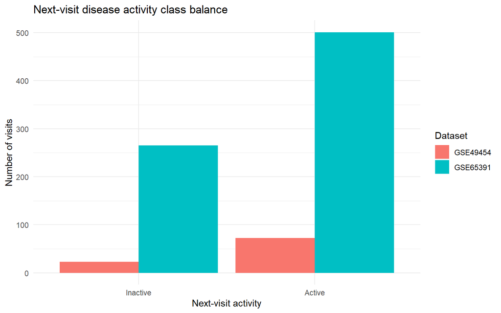

```r
ggplot(class_balance, aes(x = Future_Activity, y = Count, fill = Dataset)) +
  geom_col(position = "dodge") +
  labs(
    title = "Next-visit disease activity class balance",
    x = "Next-visit activity",
    y = "Number of visits"
  ) +
  theme_minimal()
```

### 8.2 SLEDAI distributions

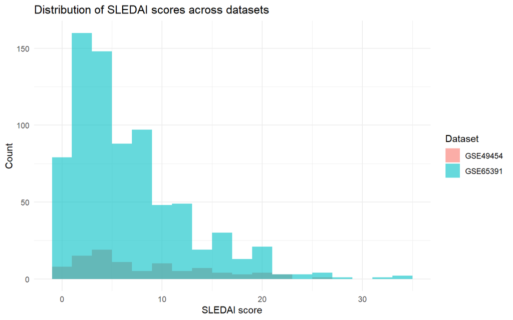

```r
plot_sledai <- rbind(
  data_65391 %>% select(dataset, sledai),
  data_49454 %>% select(dataset, sledai)
)

ggplot(plot_sledai, aes(x = sledai, fill = dataset)) +
  geom_histogram(binwidth = 2, alpha = 0.6, position = "identity") +
  labs(
    title = "Distribution of SLEDAI scores across datasets",
    x = "SLEDAI score",
    y = "Count",
    fill = "Dataset"
  ) +
  theme_minimal()
```

## 9 Feature analysis and extraction

Feature selection was performed on the training data only to avoid test-set leakage. The pipeline used variance filtering, supervised limma ranking, and random forest importance. This reduces the feature space while retaining genes that are both variable and associated with future disease activity.

## 10 Internal validation using patient-level split

This section trains and tests within GSE65391 using a patient-level split. Splitting by patient is more conservative than splitting by visit because it prevents repeated visits from the same patient appearing in both the training and test sets.

```r
split_65391 <- patient_split(data_65391, p = 0.7, seed = 42)

train_65391 <- data_65391[split_65391$train_idx, ]
test_65391  <- data_65391[split_65391$test_idx, ]

table(train_65391$next_activity)
```

```
Inactive   Active
     187      366
```

```r
table(test_65391$next_activity)
```

```
Inactive   Active
      78      135
```

### 10.1 Gene-only feature panel

```r
gene_only_internal <- prepare_matrices(
  train_data = train_65391,
  test_data = test_65391,
  gene_cols = gene_cols,
  include_clinical = FALSE,
  top_var_n = 2000,
  top_limma_n = 300,
  final_n = 50
)

dim(gene_only_internal$X_train)
```

```
[1] 553  50
```

```r
dim(gene_only_internal$X_test)
```

```
[1] 213  50
```

```r
head(gene_only_internal$final_genes, 20)
```

```
 [1] "ILMN_2079655" "ILMN_1740298" "ILMN_2112256" "ILMN_1735712" "ILMN_1674228"
 [6] "ILMN_1739508" "ILMN_3299955" "ILMN_1699214" "ILMN_1784863" "ILMN_1796316"
[11] "ILMN_3226181" "ILMN_1742001" "ILMN_1737184" "ILMN_1800626" "ILMN_1835092"
[16] "ILMN_1712918" "ILMN_1662839" "ILMN_1680274" "ILMN_2404850" "ILMN_2193233"
```

### 10.2 Gene + clinical feature panel

```r
gene_clinical_internal <- prepare_matrices(
  train_data = train_65391,
  test_data = test_65391,
  gene_cols = gene_cols,
  include_clinical = TRUE,
  top_var_n = 2000,
  top_limma_n = 300,
  final_n = 50
)

dim(gene_clinical_internal$X_train)
```

```
[1] 553  52
```

```r
dim(gene_clinical_internal$X_test)
```

```
[1] 213  52
```

### 10.3 Top selected genes

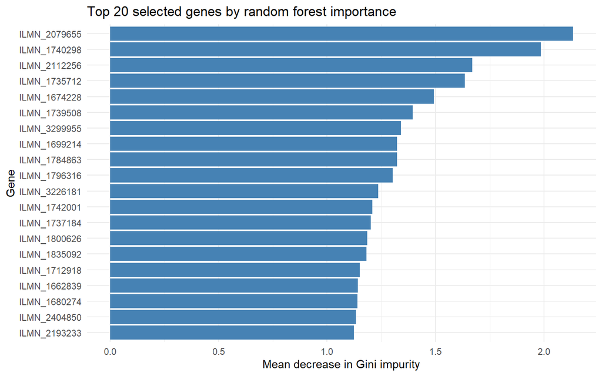

```r
top_rf <- head(gene_only_internal$rf_ranking, 20)

top_rf_df <- data.frame(
  gene = factor(names(top_rf), levels = rev(names(top_rf))),
  importance = as.numeric(top_rf)
)

ggplot(top_rf_df, aes(x = importance, y = gene)) +
  geom_col(fill = "steelblue") +
  labs(
    title = "Top 20 selected genes by random forest importance",
    x = "Mean decrease in Gini impurity",
    y = "Gene"
  ) +
  theme_minimal()
```

## 11 Modelling

Because Active and Inactive future visits are imbalanced, model evaluation emphasises balanced accuracy and AUROC rather than raw accuracy. Downsampling is applied during cross-validation for SVM and elastic net models, and random forests are trained with balanced bootstrap sampling. For SVM and elastic net, classification thresholds are selected using cross-validation predictions to maximise balanced accuracy.

### 11.1 Internal validation results

```r
internal_gene_only_results <- train_and_evaluate_models(
  gene_only_internal,
  label_prefix = "Internal gene-only"
)

internal_gene_clinical_results <- train_and_evaluate_models(
  gene_clinical_internal,
  label_prefix = "Internal gene + clinical"
)

internal_performance <- rbind(
  internal_gene_only_results$performance,
  internal_gene_clinical_results$performance
)

kable(
  internal_performance,
  caption = "Internal patient-level validation performance using GSE65391"
)
```

Internal patient-level validation performance using GSE65391

| Model | Accuracy | Balanced_Accuracy | Sensitivity | Specificity | AUC |
| --- | --- | --- | --- | --- | --- |
| Internal gene-only Random Forest | 0.643 | 0.578 | 0.822 | 0.333 | 0.652 |
| Internal gene-only SVM | 0.638 | 0.625 | 0.674 | 0.577 | 0.653 |
| Internal gene-only Elastic Net | 0.653 | 0.620 | 0.741 | 0.500 | 0.672 |
| Internal gene + clinical Random Forest | 0.714 | 0.663 | 0.852 | 0.474 | 0.737 |
| Internal gene + clinical SVM | 0.638 | 0.609 | 0.719 | 0.500 | 0.663 |
| Internal gene + clinical Elastic Net | 0.638 | 0.593 | 0.763 | 0.423 | 0.669 |

```r
internal_gene_only_results$best_thresh_svm
```

```
[1] 0.51
```

```r
internal_gene_only_results$best_thresh_glmnet
```

```
[1] 0.48
```

```r
internal_gene_clinical_results$best_thresh_svm
```

```
[1] 0.46
```

```r
internal_gene_clinical_results$best_thresh_glmnet
```

```
[1] 0.46
```

## 12 Cross-dataset external validation

To test generalisability, models are trained on GSE65391 and externally evaluated on GSE49454 using only common genes. This is stricter than a random train-test split because the test data come from an independent cohort.

```r
external_gene_only <- prepare_matrices(
  train_data = data_65391,
  test_data = data_49454,
  gene_cols = gene_cols,
  include_clinical = FALSE,
  top_var_n = 2000,
  top_limma_n = 300,
  final_n = 50
)

external_gene_clinical <- prepare_matrices(
  train_data = data_65391,
  test_data = data_49454,
  gene_cols = gene_cols,
  include_clinical = TRUE,
  top_var_n = 2000,
  top_limma_n = 300,
  final_n = 50
)

table(external_gene_only$y_train)
```

```
Inactive   Active
     265      501
```

```r
table(external_gene_only$y_test)
```

```
Inactive   Active
      23       72
```

```r
external_gene_only_results <- train_and_evaluate_models(
  external_gene_only,
  label_prefix = "External gene-only"
)

external_gene_clinical_results <- train_and_evaluate_models(
  external_gene_clinical,
  label_prefix = "External gene + clinical"
)

external_performance <- rbind(
  external_gene_only_results$performance,
  external_gene_clinical_results$performance
)

kable(
  external_performance,
  caption = "External validation performance: trained on GSE65391 and tested on GSE49454"
)
```

External validation performance: trained on GSE65391 and tested on GSE49454

| Model | Accuracy | Balanced_Accuracy | Sensitivity | Specificity | AUC |
| --- | --- | --- | --- | --- | --- |
| External gene-only Random Forest | 0.674 | 0.533 | 0.806 | 0.261 | 0.590 |
| External gene-only SVM | 0.611 | 0.492 | 0.722 | 0.261 | 0.540 |
| External gene-only Elastic Net | 0.495 | 0.519 | 0.472 | 0.565 | 0.533 |
| External gene + clinical Random Forest | 0.821 | 0.734 | 0.903 | 0.565 | 0.823 |
| External gene + clinical SVM | 0.621 | 0.617 | 0.625 | 0.609 | 0.665 |
| External gene + clinical Elastic Net | 0.695 | 0.695 | 0.694 | 0.696 | 0.737 |

```r
external_gene_only_results$best_thresh_svm
```

```
[1] 0.46
```

```r
external_gene_only_results$best_thresh_glmnet
```

```
[1] 0.51
```

```r
external_gene_clinical_results$best_thresh_svm
```

```
[1] 0.58
```

```r
external_gene_clinical_results$best_thresh_glmnet
```

```
[1] 0.46
```

## 13 Combined dataset sensitivity analysis

As a secondary analysis, the two datasets are combined to increase sample size. This may improve stability but can also introduce batch effects, so the combined result is interpreted cautiously.

```r
shared_cols <- intersect(colnames(data_65391), colnames(data_49454))

combined_data <- rbind(
  data_65391[, shared_cols],
  data_49454[, shared_cols]
)

combined_data$dataset <- factor(combined_data$dataset)

table(combined_data$dataset)
```

```
GSE49454 GSE65391
      95      766
```

```r
table(combined_data$next_activity)
```

```
Inactive   Active
     288      573
```

```r
split_combined <- patient_split(combined_data, p = 0.7, seed = 42)

train_combined <- combined_data[split_combined$train_idx, ]
test_combined  <- combined_data[split_combined$test_idx, ]

combined_gene_clinical <- prepare_matrices(
  train_data = train_combined,
  test_data = test_combined,
  gene_cols = gene_cols,
  include_clinical = TRUE,
  top_var_n = 2000,
  top_limma_n = 300,
  final_n = 50
)

combined_results <- train_and_evaluate_models(
  combined_gene_clinical,
  label_prefix = "Combined gene + clinical"
)

combined_performance <- combined_results$performance

kable(
  combined_performance,
  caption = "Combined dataset patient-level validation performance"
)
```

Combined dataset patient-level validation performance

| Model | Accuracy | Balanced_Accuracy | Sensitivity | Specificity | AUC |
| --- | --- | --- | --- | --- | --- |
| Combined gene + clinical Random Forest | 0.711 | 0.611 | 0.859 | 0.362 | 0.683 |
| Combined gene + clinical SVM | 0.698 | 0.601 | 0.840 | 0.362 | 0.637 |
| Combined gene + clinical Elastic Net | 0.685 | 0.571 | 0.853 | 0.290 | 0.670 |

```r
combined_results$best_thresh_svm
```

```
[1] 0.48
```

```r
combined_results$best_thresh_glmnet
```

```
[1] 0.41
```

## 14 Overall performance summary

```r
overall_performance <- rbind(
  internal_performance,
  external_performance,
  combined_performance
)

kable(
  overall_performance,
  caption = "Overall comparison of internal, external, and combined modelling strategies"
)
```

Overall comparison of internal, external, and combined modelling strategies

| Model | Accuracy | Balanced_Accuracy | Sensitivity | Specificity | AUC |
| --- | --- | --- | --- | --- | --- |
| Internal gene-only Random Forest | 0.643 | 0.578 | 0.822 | 0.333 | 0.652 |
| Internal gene-only SVM | 0.638 | 0.625 | 0.674 | 0.577 | 0.653 |
| Internal gene-only Elastic Net | 0.653 | 0.620 | 0.741 | 0.500 | 0.672 |
| Internal gene + clinical Random Forest | 0.714 | 0.663 | 0.852 | 0.474 | 0.737 |
| Internal gene + clinical SVM | 0.638 | 0.609 | 0.719 | 0.500 | 0.663 |
| Internal gene + clinical Elastic Net | 0.638 | 0.593 | 0.763 | 0.423 | 0.669 |
| External gene-only Random Forest | 0.674 | 0.533 | 0.806 | 0.261 | 0.590 |
| External gene-only SVM | 0.611 | 0.492 | 0.722 | 0.261 | 0.540 |
| External gene-only Elastic Net | 0.495 | 0.519 | 0.472 | 0.565 | 0.533 |
| External gene + clinical Random Forest | 0.821 | 0.734 | 0.903 | 0.565 | 0.823 |
| External gene + clinical SVM | 0.621 | 0.617 | 0.625 | 0.609 | 0.665 |
| External gene + clinical Elastic Net | 0.695 | 0.695 | 0.694 | 0.696 | 0.737 |
| Combined gene + clinical Random Forest | 0.711 | 0.611 | 0.859 | 0.362 | 0.683 |
| Combined gene + clinical SVM | 0.698 | 0.601 | 0.840 | 0.362 | 0.637 |
| Combined gene + clinical Elastic Net | 0.685 | 0.571 | 0.853 | 0.290 | 0.670 |

## 15 Results interpretation

The strongest model should be selected using balanced accuracy and AUROC rather than raw accuracy, because disease activity classes are imbalanced. If internal validation performance is higher than external validation performance, this suggests that some predictive signal is dataset-specific and may not fully generalise across independent cohorts.

## 16 Limitations

Important limitations include repeated patient visits, class imbalance, possible batch effects between GEO datasets, and differences in cohort composition or preprocessing. The external validation analysis partly addresses this by testing whether a model trained on one cohort generalises to another independent cohort.

## 17 Conclusion

Overall, this model evaluates whether longitudinal gene expression can predict future SLE disease activity. Strong internal performance would suggest a useful predictive signal, while lower external validation performance would indicate that the model requires further validation before it could be interpreted as a robust biomarker of disease progression.